[figure not shown]

6MT(TY75)-2

General Description

MANUAL TRANSMISSION AND DIFFERENTIAL

1. General Description

A: SPECIFICATION

1. MANUAL TRANSMISSION AND DIFFERENTIAL

2. TRANSMISSION GEAR OIL

CAUTION:

If an alternative transmission gear oil is used, you may not have expected functionality and perfor-

mance.

Recommended oil:

SUBARU GEAR OIL EXTRA MT

Alternative:

GL-5 (75W-90)

Type 6-forward speeds and 1-reverse (all stage with synchromesh)

Transmission gear ratio

1st 3.454

2nd 1.947

3rd 1.296

4th 0.972

5th 0.780

6th 0.666

Rev. 3.636

Front reduction

gear

Final

Type of gear Hypoid

Gear ratio 4.111

Rear reduction

gear

Transfer

Type of gear Helical

Gear ratio 1.000

Final

Type of gear Hypoid

Gear ratio 4.111

Front differential Type and number of gear Straight bevel gear (bevel pinion: 2, bevel gear: 2)

Center differential Type and number of gear Straight bevel gear (bevel pinion: 2, bevel gear: 2, viscous coupling)

Transmission gear oil capacity 3.3 L (3.5 US qt, 2.9 Imp qt)

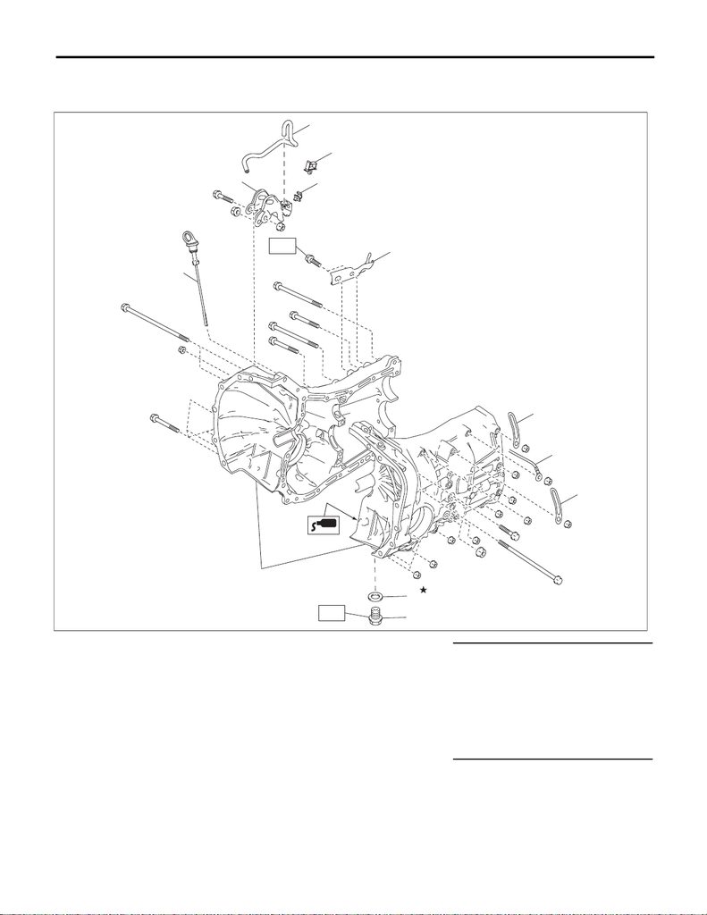

6MT(TY75)-3

General Description

MANUAL TRANSMISSION AND DIFFERENTIAL

B: COMPONENT

1. TRANSMISSION CASE

(1) Air breather hose (7) Transmission radio ground cord Tightening torque: N·m (kgf-m, ft-lb)

(2) Clamp (8) Gasket T1: 18 (1.8, 13.3)

(3) Hose clamp (9) Drain plug T2: 44 (4.5, 32.5) (aluminum gasket,

silver)

(4) Pitching stopper bracket (10) Transmission case ASSY 70 (7.1, 51.6) (copper gasket,

brown)

(5) Select bracket (11) Oil level gauge 70 (7.1, 51.6) (metal gasket,

black)

(6) Harness clip

MT-03077

(10)

(1)

(2)

(5)

(6)

(7)

(6)

(3)

(4)

(11)

(9)

(8)

T1

T2

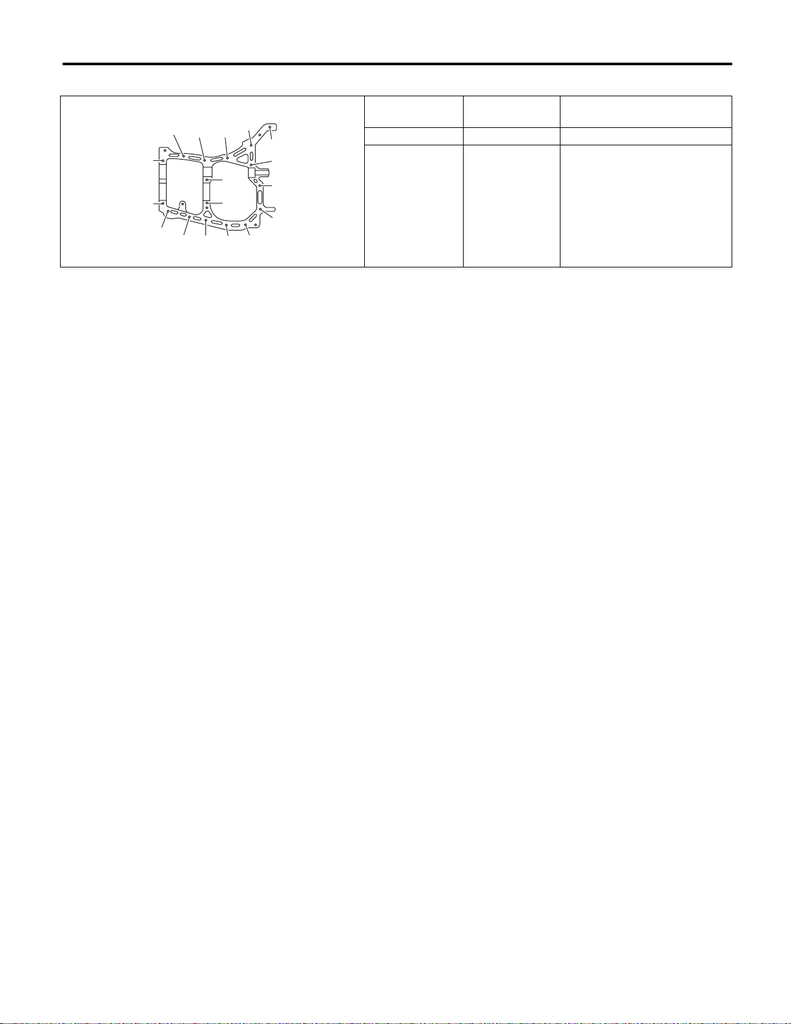

6MT(TY75)-4

General Description

MANUAL TRANSMISSION AND DIFFERENTIAL

Transmission case tightening torque

Bolt No.

Bolt size

mm

Tightening torque:

N·m (kgf-m, ft-lb)

(5) — (15) 8 25 (2.5, 18.4)

(1) — (4)

(16), (17)

10 40 (4.1, 29.5)

MT-00003

(9)

(5)

(7)

(16)

(17)

(3)

(4)

(11)

(1)

(2)

(6)

(8)

(10)

(12)

(14)

(13)

(15)

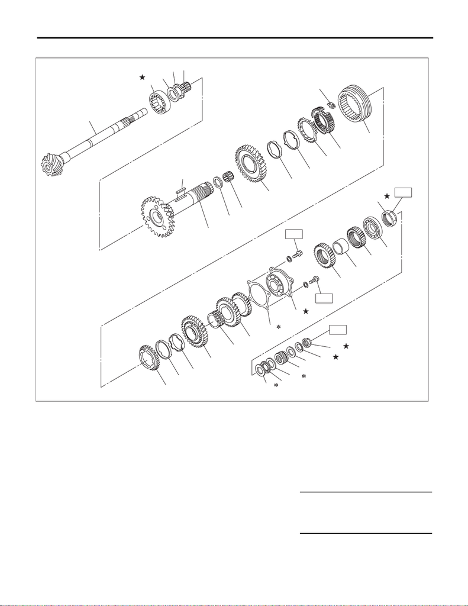

6MT(TY75)-5

General Description

MANUAL TRANSMISSION AND DIFFERENTIAL

2. DRIVE PINION ASSEMBLY

(1) Drive pinion shaft (15) 1st-2nd shifting insert (29) Lock nut

(2) Roller bearing (16) 1st-2nd coupling sleeve (30) Adjusting washer

(3) Washer (17) 2nd outer baulk ring (31) Thrust bearing

(4) Thrust bearing (18) 2nd synchro cone (32) Differential bevel gear sleeve

(5) Needle bearing (19) 2nd inner baulk ring (33) Washer

(6) Driven shaft (20) 2nd driven gear (34) Lock washer

(7) Key (21) 2nd driven gear bushing (35) Lock nut

(8) Drive pinion collar (22) 3rd-4th driven gear

(9) Needle bearing (23) Drive pinion shim Tightening torque: N·m (kgf-m, ft-lb)

(10) 1st driven gear (24) Double ball bearing T1: 30 (3.1, 22.1)

(11) 1st inner baulk ring (25) 5th driven gear T2: 126 (12.8, 92.9)

(12) 1st synchro cone (26) Drive pinion spacer T3: 440 (44.9, 324.5)

(13) 1st outer baulk ring (27) 6th driven gear

(14) 1st-2nd synchronizer hub (28) Ball bearing

MT-02954

(5)

(4)

(1)

(23)

(24)

(27)

(29)

(19)

(20)

(21)

(31)

(30)

(32)

(33)

(34)

(22)

(18)

(16)

(17)

(6)

(3)

(2)

(9)

(8)

(7)

(10)

T1

T3

(35)

T2

(30)

(28)

(26)

(25)

(11)

(12)

(13)

(14)

(15)

T1

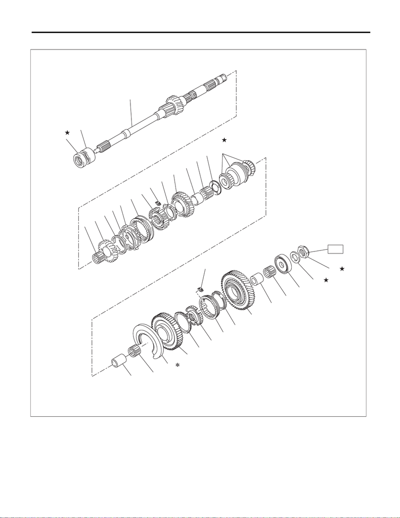

6MT(TY75)-6

General Description

MANUAL TRANSMISSION AND DIFFERENTIAL

3. MAIN SHAFT ASSY

(3)

(2)

(1)

T

(23)

(24)

(25)

(26)

(27)

(31)

(32)

(30)

(29)

(28)

(22)

(21)

(18)

(20)

(19)

(15)

(16)

(17)

(10)

(11)

(13)

(12)

(14)

(4)

(5)

(6)

(8)

(7)

(9)

MT-02955

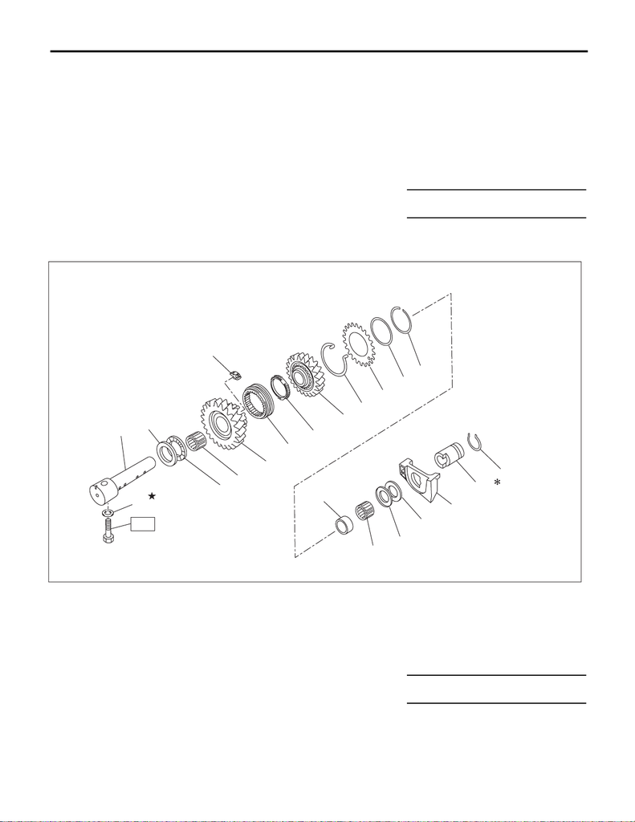

6MT(TY75)-7

General Description

MANUAL TRANSMISSION AND DIFFERENTIAL

(1) Oil seal (13) 4th drive gear (25) 5th-6th coupling sleeve

(2) Needle bearing (14) 4th needle bearing race (26) 6th baulk ring

(3) Main shaft (15) Needle bearing (27) 6th drive gear

(4) Needle bearing (16) 4th gear thrust washer (28) 6th needle bearing race

(5) 3rd drive gear (17) Double taper roller bearing (29) Needle bearing

(6) 3rd inner baulk ring (18) 5th needle bearing race (30) Ball bearing

(7) 3rd synchro cone (19) Needle bearing (31) Lock washer

(8) 3rd outer baulk ring (20) Main shaft rear plate (32) Lock nut

(9) 3rd-4th coupling sleeve (21) 5th drive gear

(10) 3rd-4th synchronizer hub (22) 5th baulk ring Tightening torque: N·m (kgf-m, ft-lb)

(11) 3rd-4th shifting insert (23) 5th-6th synchronizer hub T: 160 (16.3, 118.0)

(12) 4th baulk ring (24) 5th-6th shifting insert

(1) Reverse idler gear shaft (9) Reverse idler gear (17) Gasket

(2) Reverse idler gear washer (10) Reverse idler gear collar (18) Spring

(3) Thrust bearing (11) Needle bearing (19) Reverse idler sub gear

(4) Needle bearing (12) Thrust bearing (20) Friction plate

(5) Reverse idler gear No. 2 (13) Reverse idler gear washer (21) Snap ring

(6) Reverse coupling sleeve (14) Oil case guide

(7) Reverse baulk ring (15) Reverse idler gear bushing Tightening torque: N·m (kgf-m, ft-lb)

(8) Reverse shifting insert (16) Snap ring T: 25 (2.5, 18.4)

MT-03154

(15)

(16)

(14)

(13)

(10)

(11)

(12)

(18)

(19)

(20)

(21)

(9)

(6)

(5)

(7)

(4)

(3)

T

(1)

(2)

(17)

(8)

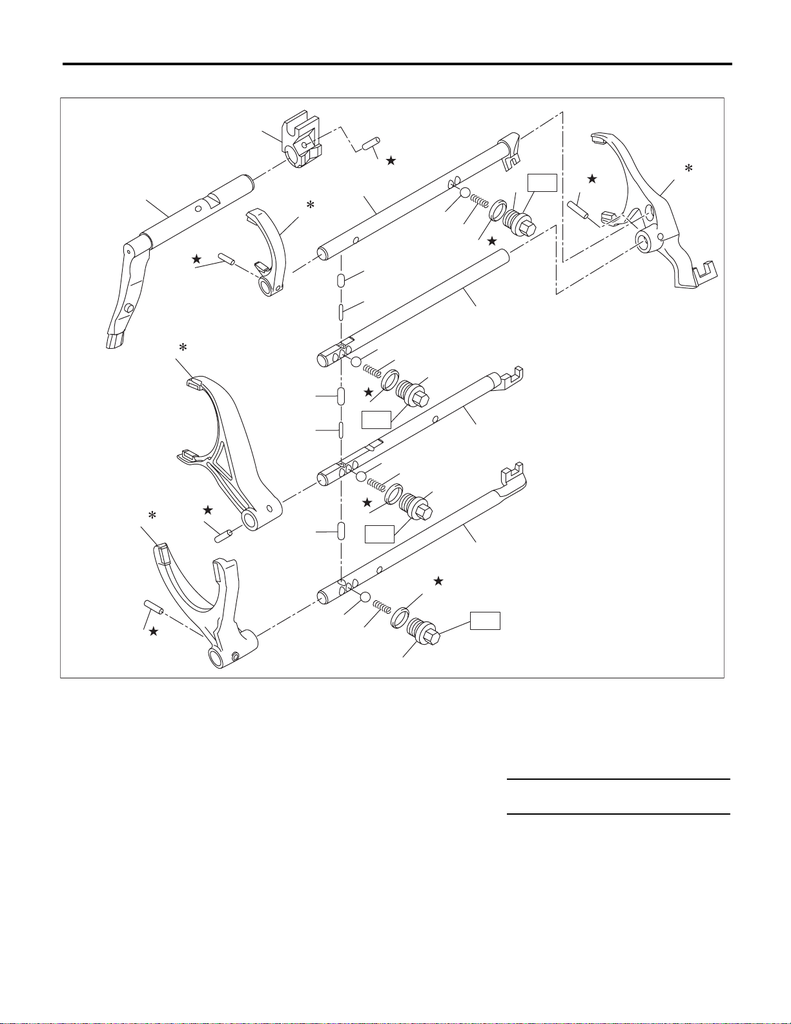

6MT(TY75)-8

General Description

MANUAL TRANSMISSION AND DIFFERENTIAL

5. SHIFTER FORK AND SHIFTER ROD

(1) Shifter arm (8) 3rd-4th shifter fork (15) Checking ball plug

(2) Selector arm (9) 3rd-4th fork rod (16) Checking ball spring

(3) Straight pin (10) 1st-2nd shifter fork (17) Check ball

(4) Reverse shifter fork (11) 1st-2nd fork rod (18) Gasket

(5) Reverse fork rod (12) Interlock plunger

(6) 5th-6th shifter fork (13) Interlock plunger Tightening torque: N·m (kgf-m, ft-lb)

(7) 5th-6th fork rod (14) Interlock plunger T: 20 (2.0, 14.8)

MT-02413

(3)

(3)

(3)

(3)

(3)

(2)

(1)

(4)

(12)

(10)

(8)

(6)

(12)

(13)

(14)

(5)

(13)

(17)

(16)

(15)

(17)

(16)

(15)

(7)

(9)

(11)

T

(17)

(16)

(15)

T

(17)

(16)

(15)

T

T

(18)

(18)

(18)

(18)

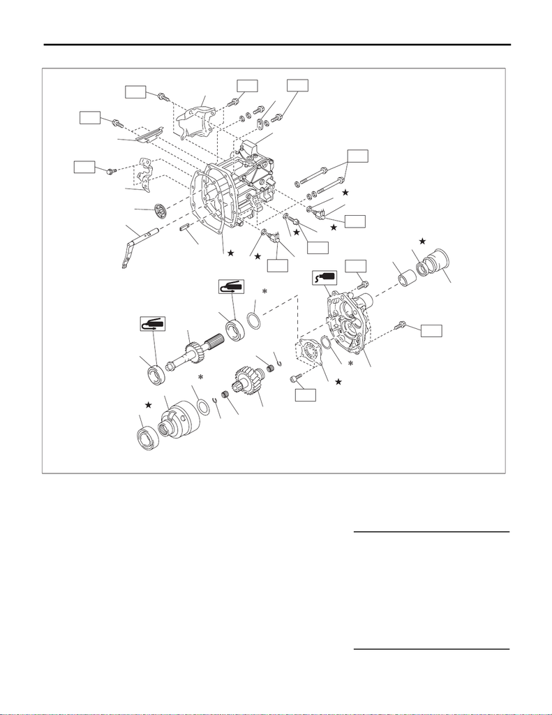

6MT(TY75)-9

General Description

MANUAL TRANSMISSION AND DIFFERENTIAL

6. TRANSFER CASE AND EXTENSION

(1) Shifter arm (15) Center differential (29) Precoat bolt

(2) Interlock plate (16) Adjusting washer (30) Needle bearing

(3) Gasket (17) Transfer drive gear (31) Snap ring

(4) Transfer case (18) Ball bearing

(5) Transmission hanger (19) Snap ring Tightening torque: N·m (kgf-m, ft-lb)

(6) Gasket (20) Extension case T1: 15 (1.5, 11.1)

(7) Gasket (21) Bushing T2: 18 (1.8, 13.3)

(8) Neutral position switch (22) Oil seal T3: 20 (2.0, 14.8)

(9) Back-up light switch (23) Dust cover T4: 24.5 (2.5, 18.1)

(10) Taper roller bearing (transfer case

side)

(24) Transfer cover T5: 26 (2.7, 19.2)

(11) Transfer driven gear (25) Dust cover T6: 32.3 (3.3, 23.8)

(12) Taper roller bearing (extension

case side)

(26) Shift bracket T7: 40 (4.1, 29.5)

(13) Adjusting washer (27) Oil guide

(14) Ball bearing (28) Gasket

MT-03203

(8)

T3

(6)

(5)

(25)

(22)

T7

T2

T4

(21)

(24)

T1

T1

T1

T6

T4

(29)

(7)

(9)

T6

(28)

(3)

(1)

(2)

(26)

(27)

(23)

T5

(19)

(18)

(20)

T7

(16)

(15)

(14)

(17)

(31)

(30)

(30)

(31)

(10)

(11)

(12)

(13)

(4)

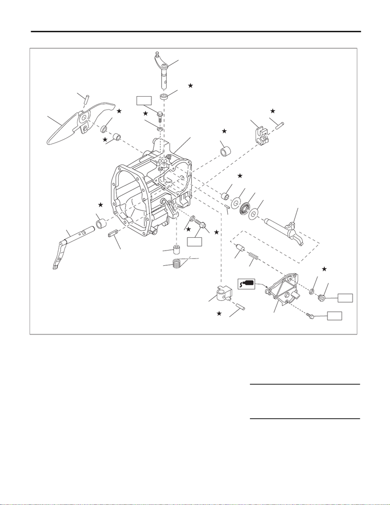

6MT(TY75)-10

General Description

MANUAL TRANSMISSION AND DIFFERENTIAL

7. SHIFT LINK ASSEMBLY

(1) Selector lever COMPL (11) Thrust bearing (21) Seal ring

(2) Selector arm No. 2 (12) Oil seal (22) Needle bearing

(3) Shifter arm collar (13) Straight pin (23) Roller bearing

(4) Neutral set spring (14) Transfer case (24) Precoat bolt

(5) Straight pin (15) Gasket

(6) Selector arm (16) Checking ball spring Tightening torque: N·m (kgf-m, ft-lb)

(7) Shifter arm (17) Plunger T1: 6.4 (0.7, 4.7)

(8) Shift lever COMPL (18) Seal bolt T2: 20 (2.0, 14.8)

(9) Shifter arm No. 2 (19) Interlock plate T3: 25 (2.5, 18.4)

(10) Washer (20) Transmission cover

MT-03083

(16)

(18)

(17)

(20)

(21)

(15)

(10)

(10)

(24)

(9)

(11)

(1)

(12)

(3)

(4)

(6)

(5)

(5)

(2)

(13)

T2

T3

T3

(14)

(22)

(23)

(15)

(8)

(5)

(12)

(7)

(19)

T1

(22)

(23)

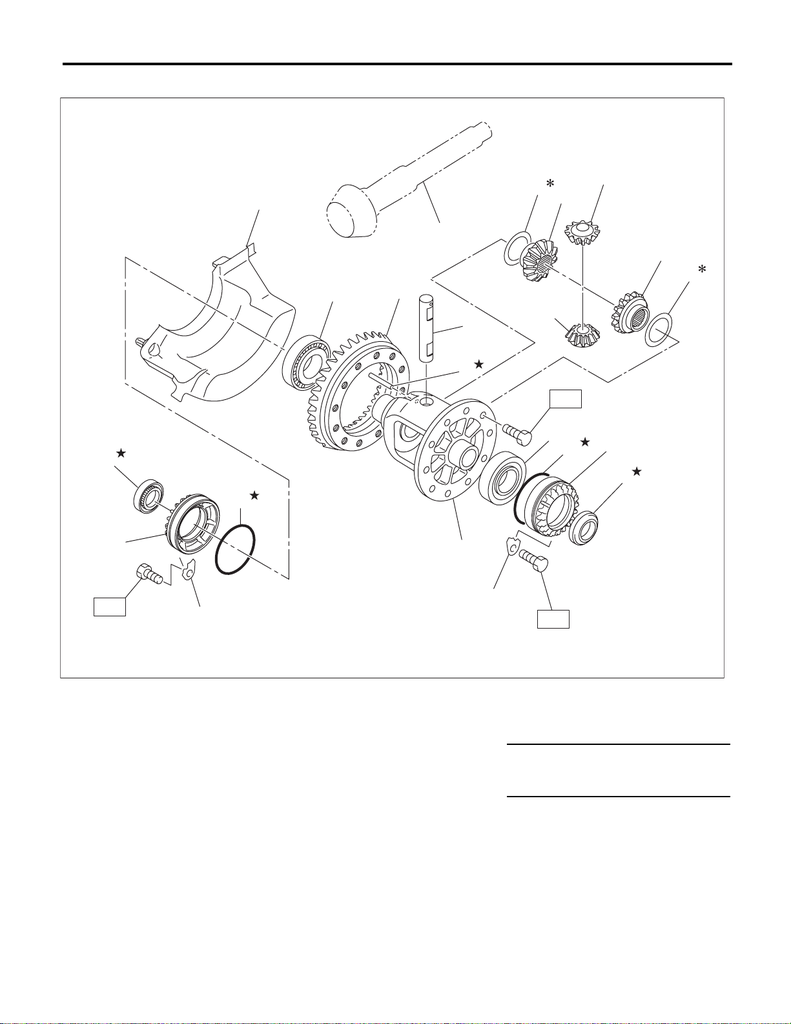

6MT(TY75)-11

General Description

MANUAL TRANSMISSION AND DIFFERENTIAL

8. FRONT DIFFERENTIAL

(1) Drive pinion shaft (7) Differential bevel pinion (13) Retainer lock plate

(2) Hypoid driven gear (8) Taper roller bearing (14) Front oil guide

(3) Pinion shaft (9) Differential case

(4) Straight pin (10) Oil seal Tightening torque: N·m (kgf-m, ft-lb)

(5) Adjusting washer (11) Differential side retainer T1: 25 (2.5, 18.4)

(6) Differential bevel gear (12) O-ring T2: 62 (6.3, 45.7)

MT-02750

(12)

(10)

(1)

(2)

T1

T2

(5)

(5)

(6)

(9)

(7)

(7)

(12)

(8)

(14)

(8)

(13)

(11)

(11)

(10)

(13)

T1

(4)

(3)

(6)

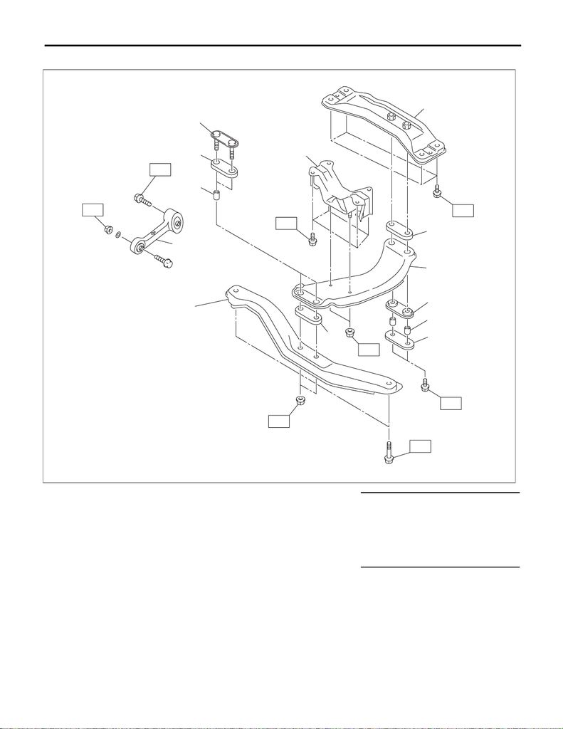

6MT(TY75)-12

General Description

MANUAL TRANSMISSION AND DIFFERENTIAL

9. TRANSMISSION MOUNTING

(1) Pitching stopper (7) Upper cushion rubber Tightening torque: N·m (kgf-m, ft-lb)

(2) Spacer (8) Center crossmember T1: 35 (3.6, 25.8)

(3) Lower cushion rubber (9) Front crossmember T2: 50 (5.1, 36.9)

(4) Front plate (10) Rear cushion rubber T3: 58 (5.9, 42.8)

(5) Transmission cushion rubber (11) Rear plate T4: 70 (7.1, 51.6)

(6) Rear crossmember T5: 140 (14.3, 103.3)

(1)

T3

T4

T4

T4

T1

T5

T1

T2

(2)

(4)

(5)

(10)

(8)

(7)

(3)

(2)

(11)

(6)

(3)

(9)

MT-01795

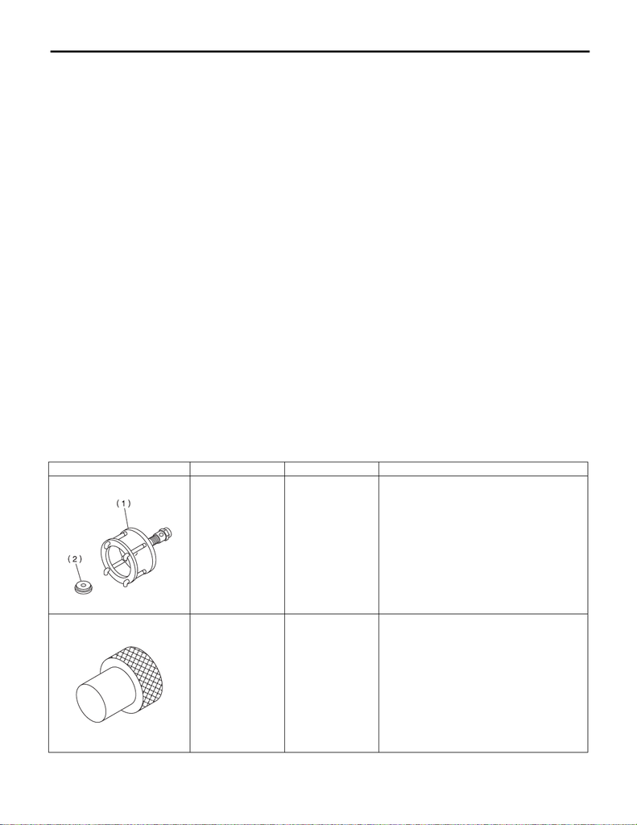

6MT(TY75)-13

General Description

MANUAL TRANSMISSION AND DIFFERENTIAL

C: CAUTION

• Remove contamination including dirt and corrosion before removal, installation or disassembly.

• Keep the disassembled parts in order and protect them from dust and dirt.

• Before removal, installation or disassembly, be sure to clarify the failure. Avoid unnecessary removal, in-

stallation, disassembly and replacement.

• When disassembling the case and other light alloy parts, disassemble by using a plastic hammer. Do not

pry apart with screwdrivers or other tools.

• Vehicle components are extremely hot after driving. Be wary of receiving burns from heated parts.

• Use SUBARU genuine gear oil, grease or equivalent. Do not mix gear oil, grease, etc. of different grades

or manufacturers.

• Be sure to tighten fasteners including bolts and nuts to the specified torque.

• Place shop jacks or rigid racks at the specified points.

• Apply gear oil onto sliding or revolving surfaces before installation.

• Replace deformed or damaged snap rings with new parts.

• Before installing O-rings or oil seals, apply sufficient amount of gear oil to avoid damage and deformation.

• Be careful not to incorrectly install or fail to install O-rings, snap rings and other such parts.

• Before securing a part on a vise, place cushioning material such as wood blocks, aluminum plate, or cloth

between the part and the vise.

• Avoid damaging the mating surface of the case.

• Before applying liquid gasket, completely remove and clean the old liquid gasket.

• Be careful of handling the oil seal, O-ring and gasket. If the contact surface of them is damaged, oil leakage

may occur.

• When pressing-in the oil seal, make sure that the oil seal lip portion and outer surface are not damaged or

tilted.

• When replacing the taper roller bearing, replace the outer race and inner race as a set.

• When replacing the hypoid gear, replace the hypoid driven gear and drive pinion shaft as a set.

• Replace the bolts if the seating surface or the thread surface is excessively rusted.

D: PREPARATION TOOL

1. SPECIAL TOOL

ILLUSTRATION TOOL NUMBER DESCRIPTION REMARKS

899524100 PULLER SET Used for removing the front differential taper

roller bearing inner race.

(1) Puller

(2) Cap

399780104 WEIGHT Used for adjusting preload on the front differen-

tial taper roller bearing.

ST-899524100

ST-399780104

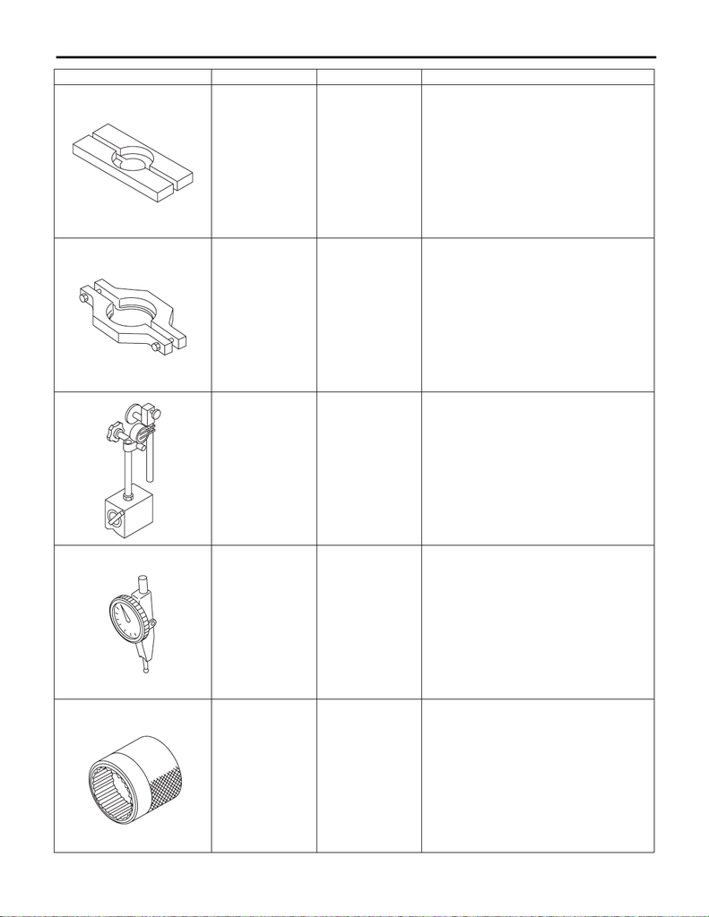

6MT(TY75)-14

General Description

MANUAL TRANSMISSION AND DIFFERENTIAL

498077000 REMOVER • Used for removing the roller bearing and

washer of the drive pinion shaft.

• Used for removing the transfer driven gear

taper roller bearing.

498077600 CENTER DIFFER-

ENTIAL BEARING

REMOVER

Used for removing the center differential ball

bearing.

498247001 MAGNET BASE • Used for measuring the backlash of differential

bevel pinion gear and hypoid driven gear.

• Used together with DIAL GAUGE

(498247100).

498247100 DIAL GAUGE • Used for measuring the backlash of differential

bevel pinion gear and hypoid driven gear.

• Used together with MAGNET BASE

(498247001).

18667AA020 HOLDER • Used for removing and installing the drive pin-

ion shaft lock nut.

• Used for measuring the backlash of hypoid

driven gear.

• Used for adjusting preload on the front differ-

ential taper roller bearing.

ILLUSTRATION TOOL NUMBER DESCRIPTION REMARKS

ST-498077000

ST-498077600

ST-498247001

ST-498247100

ST18667AA020

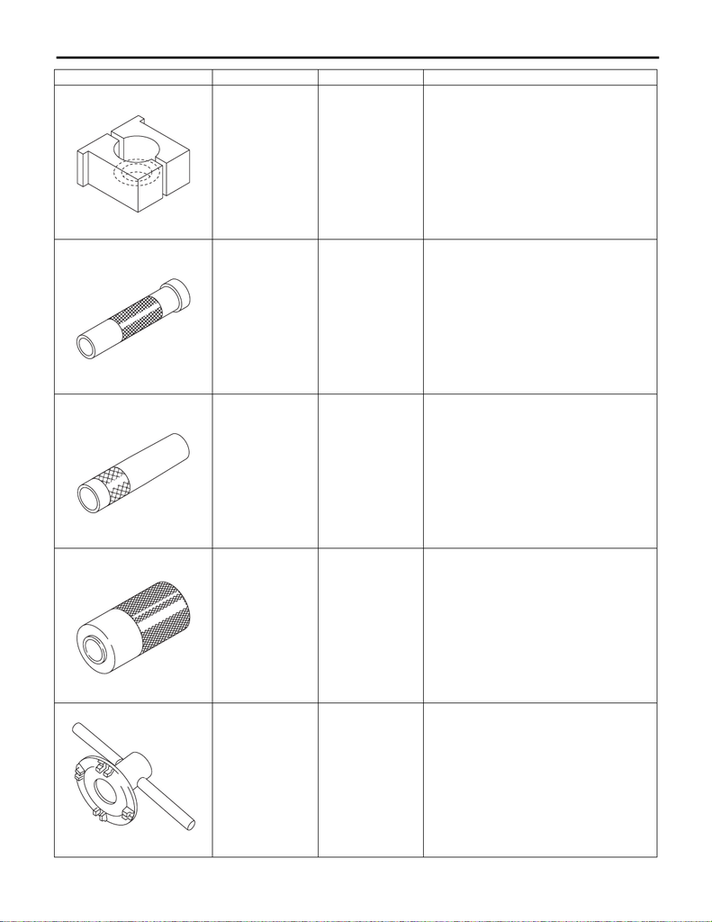

6MT(TY75)-15

General Description

MANUAL TRANSMISSION AND DIFFERENTIAL

498937000 TRANSMISSION

HOLDER

Used for removing and installing the main shaft

lock nut.

499277100 BUSHING 1-2

INSTALLER

• Used for installing the drive pinion shaft

washer.

• Used for installing the front differential taper

roller bearing outer race.

499277200 INSTALLER • Used for installing the 3rd-4th driven gear, 5th

driven gear, ball bearing and 6th driven gear

onto the driven shaft.

• Used for installing the drive pinion shaft

washer.

927640000 INSTALLER Used for installing the taper roller bearing (trans-

fer case side) of transfer driven gear.

18630AA010 WRENCH COMPL

RETAINER

• Used for removing and installing the differen-

tial side retainer.

• Used for adjusting preload on the front differ-

ential taper roller bearing.

• WRENCH COMPL RETAINER (499787000)

can also be used.

ILLUSTRATION TOOL NUMBER DESCRIPTION REMARKS

ST-498937000

ST-499277100

ST-499277200

ST-927640000

ST18630AA010

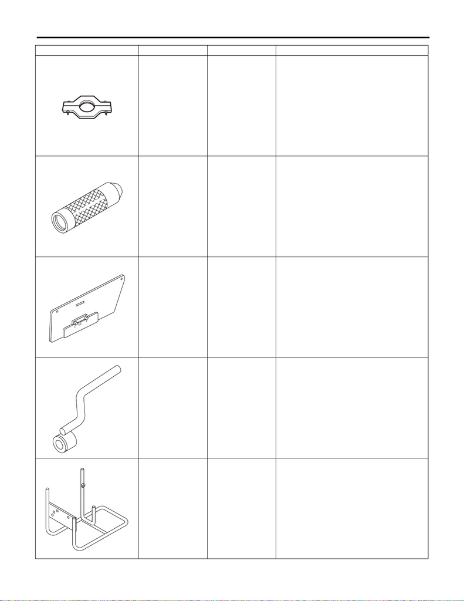

6MT(TY75)-16

General Description

MANUAL TRANSMISSION AND DIFFERENTIAL

18722AA010 REMOVER Used for removing the 5th drive gear and 6th

drive gear.

499877000 RACE 4-5

INSTALLER

• Used for installing the 4th, 5th and 6th drive

gear needle bearing races and the main shaft

double taper roller bearings.

• Used together with REMOVER (899714110).

499917500 DRIVE PINION

GAUGE ASSY

Used for adjusting the drive pinion shaft shim.

499927100 HANDLE Used for backlash measurement of the hypoid

driven gear and preload adjustment of the front

differential taper roller bearing.

499937100 TRANSMISSION

STAND

Used for disassembling and assembling the

transmission.

ILLUSTRATION TOOL NUMBER DESCRIPTION REMARKS

ST18722AA010

ST-499877000

ST-499917500

ST-499927100

ST-499937100

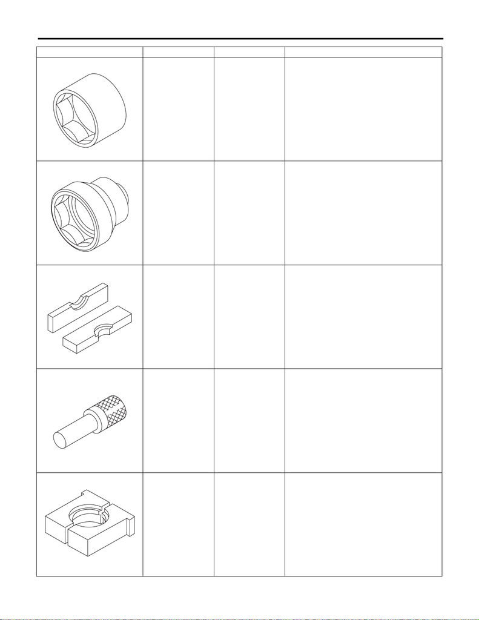

6MT(TY75)-17

General Description

MANUAL TRANSMISSION AND DIFFERENTIAL

499987003 SOCKET WRENCH

(35)

Used for removing and installing the main shaft

lock nut.

499987300 SOCKET WRENCH

(50)

Used for removing and installing the driven shaft

lock nut.

899714110 REMOVER Used for removing and installing the parts of

main shaft and driven shaft.

899864100 REMOVER • Used for removing the parts of the main shaft.

• Used for removing the transfer driven gear

taper roller bearing (transfer case side) and for

installing it (extension case side).

• Used for removing the transfer drive gear ball

bearing.

• Used for installing the transfer case roller bear-

ing.

18680AA020 HOLDER • Used for removing and installing the drive pin-

ion shaft lock nut.

• Used for removing and installing the driven

shaft lock nut.

ILLUSTRATION TOOL NUMBER DESCRIPTION REMARKS

ST-499987003

ST-499987300

ST-899714110

ST-899864100

ST18680AA020

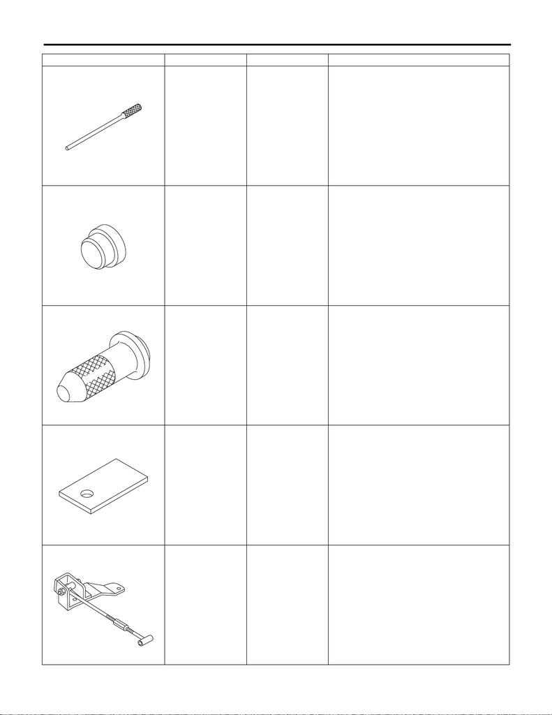

6MT(TY75)-18

General Description

MANUAL TRANSMISSION AND DIFFERENTIAL

899904100 STRAIGHT PIN

REMOVER

Used for removing and installing the straight pin.

398497701 ADAPTER • Used for installing the front differential taper

roller bearing.

• Used together with BUSHING 1-2 INSTALLER

(499277100).

498057300 INSTALLER Used for installing the extension case oil seal.

498255400 PLATE Used for measuring the hypoid driven gear back-

lash.

41099AC000 ENGINE SUPPORT

ASSY

Used for removing and installing transmission.

ILLUSTRATION TOOL NUMBER DESCRIPTION REMARKS

ST-899904100

ST-398497701

ST-498057300

ST-498255400

ST41099AC000

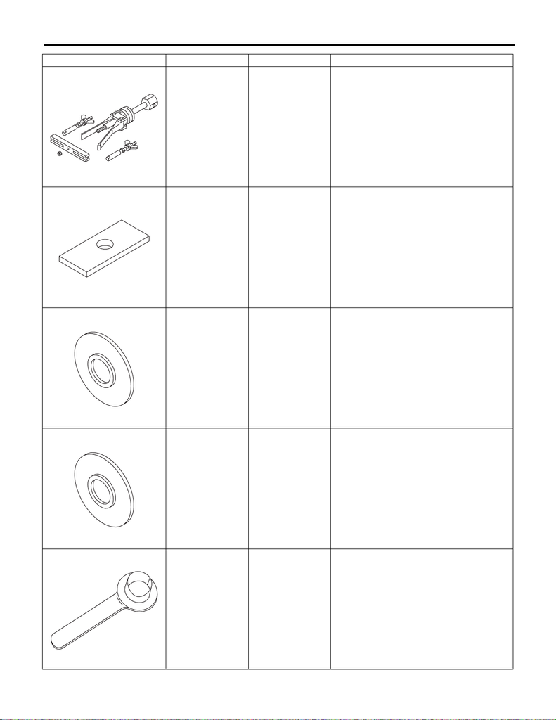

6MT(TY75)-19

General Description

MANUAL TRANSMISSION AND DIFFERENTIAL

398527700 PULLER ASSY • Used for removing the extension case oil seal.

• Used for removing the front differential taper

roller bearing outer race.

• Used for removing the front differential side

retainer oil seal.

398643600 GAUGE Used for adjusting the extension end play.

398177700 INSTALLER • Used for installing the transfer drive gear ball

bearing.

• Used for installing the 4th drive gear needle

bearing race.

498175500 INSTALLER Used for installing the taper roller bearing of

transfer driven gear (extension case side).

28399SA010 OIL SEAL PROTEC-

TOR

Used for protecting the oil seal from damage

when inserting the front drive shaft.

ILLUSTRATION TOOL NUMBER DESCRIPTION REMARKS

ST-398527700

ST-398643600

ST-398177700

ST-498175500

ST28399SA010

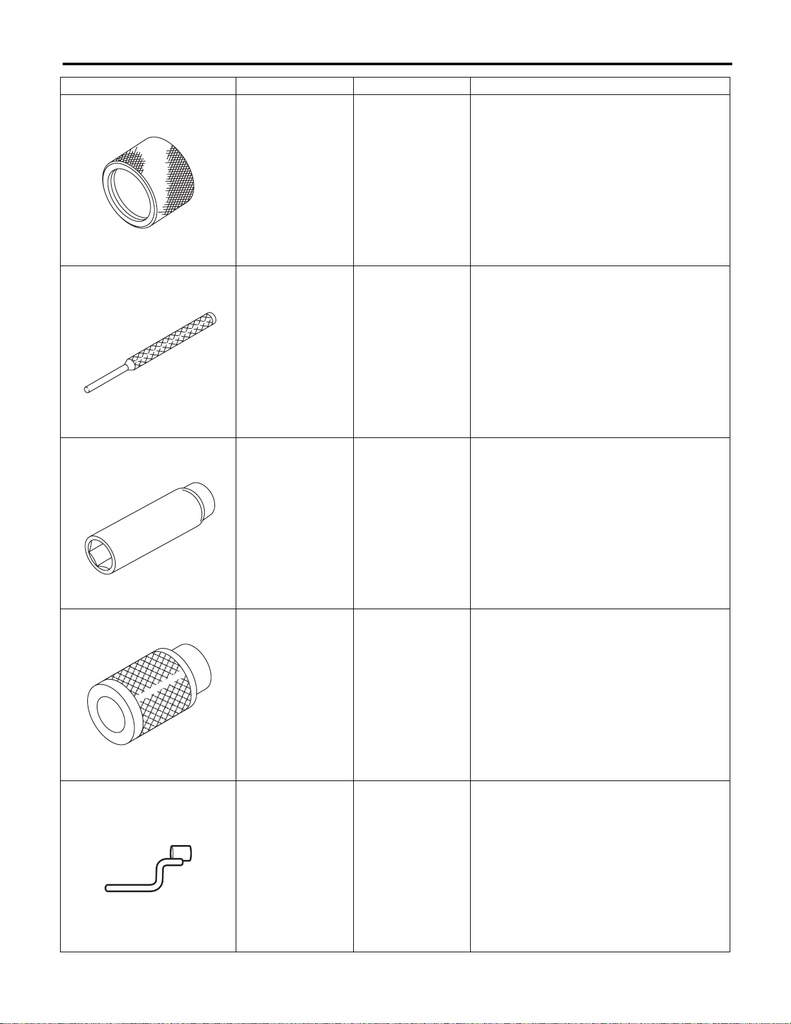

6MT(TY75)-20

General Description

MANUAL TRANSMISSION AND DIFFERENTIAL

18675AA000 DIFFERENTIAL

SIDE OIL SEAL

INSTALLER

Used for installing the front differential side

retainer oil seal.

398791700 SPRING PIN

REMOVER 2

Used for removing and installing the straight pin.

18662AA010 SOCKET (27) • Used for removing and installing the drive pin-

ion shaft lock nut.

• Used for measuring the starting torque of the

drive pinion shaft.

899754112 PRESS • Used for removing driven shaft parts.

• Used to install the main shaft ball bearing.

18631AA000 HANDLE Used for installing transfer case assembly and

extension case assembly.

ILLUSTRATION TOOL NUMBER DESCRIPTION REMARKS

ST18675AA000

ST-398791700

ST18662AA010

ST-899754112

ST18631AA000

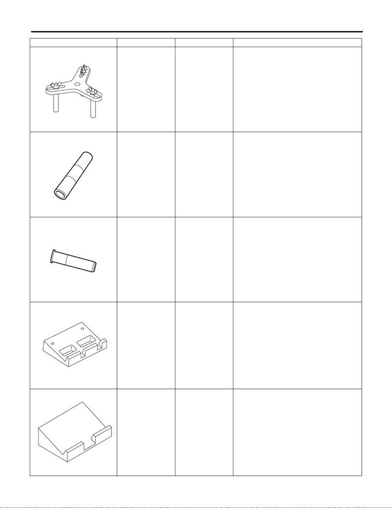

6MT(TY75)-21

General Description

MANUAL TRANSMISSION AND DIFFERENTIAL

18762AA001 COMPRESSOR

SPECIAL TOOL

• Used for removing the 1st driven gear.

• COMPRESSOR SPECIAL TOOL

(18762AA000) can also be used.

18654AA000 INSTALLER Used for installing the 2nd driven gear bushing.

18657AA000 INSTALLER Used for installing the transfer case oil seal.

498267200 CYLINDER HEAD

TABLE

Used for removing and installing the roller bear-

ing of the transfer case.

498267300 CYLINDER HEAD

TABLE

Used for removing and installing the roller bear-

ing of the transfer case.

ILLUSTRATION TOOL NUMBER DESCRIPTION REMARKS

ST18762AA001

ST18654AA000

ST18657AA000

ST-498267200

ST-498267300

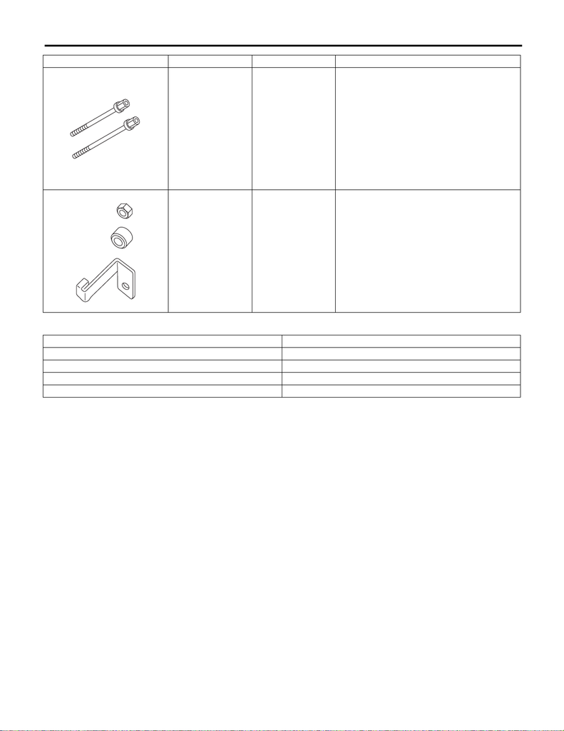

6MT(TY75)-22

General Description

MANUAL TRANSMISSION AND DIFFERENTIAL

2. GENERAL TOOL

18763AA000 COMPRESSOR

SHAFT

Used for removing and installing the needle

bearing of the transfer case.

498277200 STOPPER SET • Used for installing the needle bearing of the

transfer case.

• Use only the spacer.

TOOL NAME REMARKS

Circuit tester Used for measuring resistance.

TORX

®

bit T70 Used for removing and installing differential gear oil drain plug.

Spring pin remover Used for removing and installing the spring pin. (3 — 3.3 mm)

Socket driver (TORX

®

45 size, tamper resistant type) Used for removing and installing interlock plate.

ILLUSTRATION TOOL NUMBER DESCRIPTION REMARKS

ST18763AA000

ST-498277200